# Homework 4

Adam Grottoli

March 4, 2020

```r
iceberg=read.csv('titanic.csv')
```

## Question 2

Gender and age will have an effect on survival because women and children were given priority when the ship was being evacuated. Therefore females and younger individuals will have higher survival. Number of parents/children on board will have an effect on survival because people with children on board would have been more likely to get on a lifeboat with their children.

Price of ticket and class will have an effect on survival because people in cabins closer to the upper deck will have had to travel less distance to reach a lifeboat and will have higher survival. People with more expensive tickets are likely located closer to the upper deck and will have higher survival. People in a higher class are likely located closer to the upper deck and will have higher survival.

## Question 3

```r
library(vcd)
```

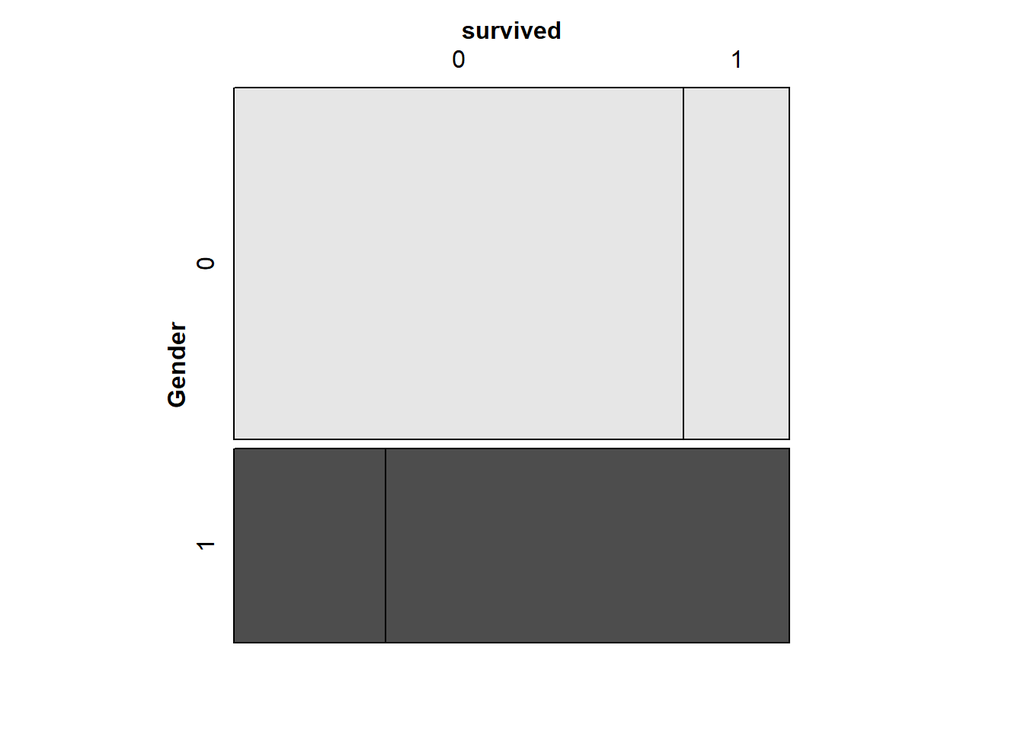

```r
mosaic(survived~Gender, data=iceberg)
```

Figure 1. A comparision of the proportion of males and females who survived. The area of each square is representative of the number of individuals in that class.

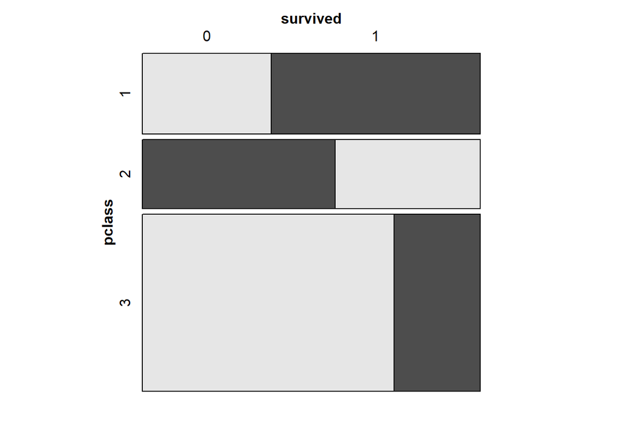

```r
mosaic(survived~pclass, data=iceberg)
```

Figure 2. A comparision of the proportion of people who survived in 1st vs. 2nd, vs 3rd class. The area of each square is representative of the number of individuals in that class.

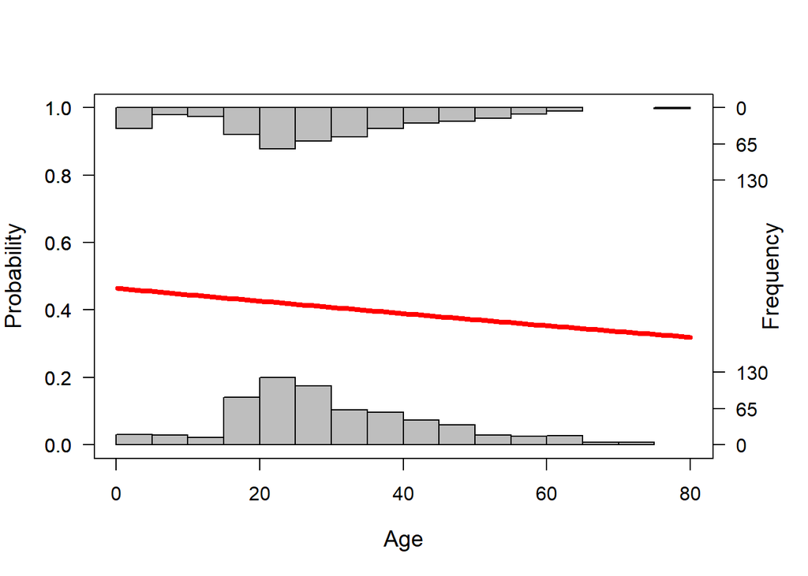

```r
library(popbio)
iceberg.nona<-na.omit(data.frame("age"=iceberg$age,"survive"=iceberg$survived, 'fare'=iceberg$fare, 'sibling'=iceberg$sibsp, 'family'=iceberg$parch))
logi.hist.plot(iceberg.nona$age,iceberg.nona$survive,boxp=FALSE,type="hist",col="gray", xlabel="Age")
```

Figure 3. The observed number of individuals who survived and died compared to age. The frequency of people in a given age class who surived and died is on top and bottom, respectively. The observed probability of survival in terms of age is given by the red line.

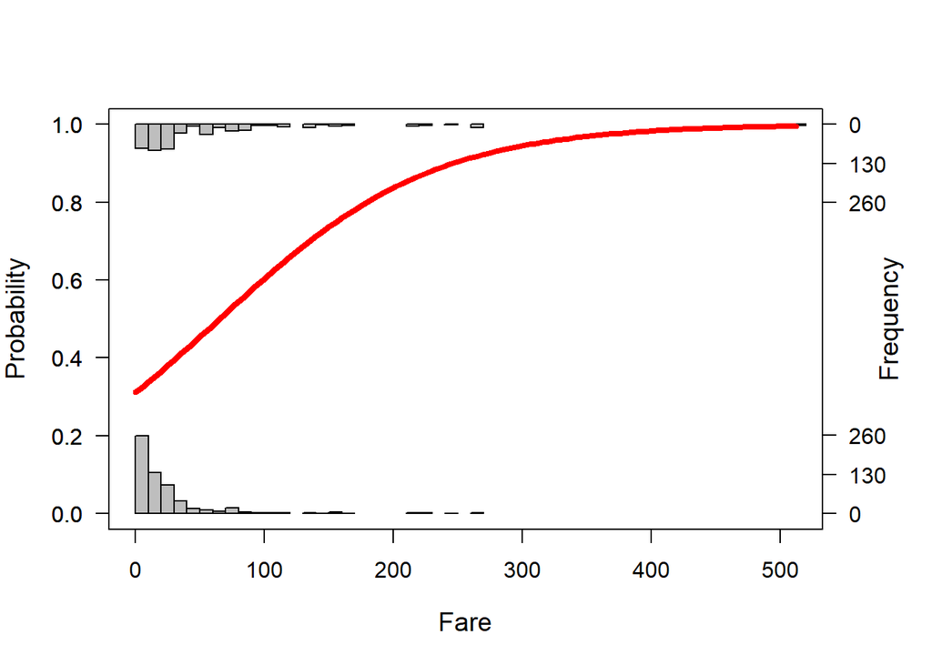

```r
logi.hist.plot(iceberg.nona$fare,iceberg.nona$survive,boxp=FALSE,type="hist",col="gray", xlabel="Fare", int=10)
```

Figure 4. The observed number of individuals who survived and died compared to fare. The frequency of people in a fare class who surived and died is on top and bottom, respectively. The observed probability of survival in terms of fare is given by the red line.

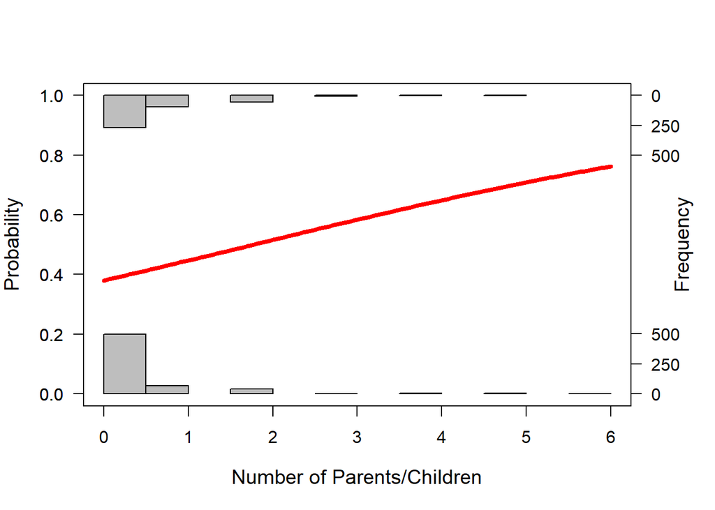

```r
logi.hist.plot(iceberg.nona$family,iceberg.nona$survive,boxp=FALSE,type="hist",col="gray", xlabel="Number of Parents/Children")
```

Figure 5. The observed number of individuals who survived and died compared to the number of children/parents on board. The frequency of people in a given class who surived and died is on top and bottom, respectively. The observed probability of survival in terms of number of children/parents is given by the red line.

## Question 4

```r
library(bestglm)
survive.vars=data.frame("age"=iceberg$age, 'fare'=iceberg$fare, 'sex'=iceberg$Gender,'family'=iceberg$parch, 'class'=iceberg$pclass ,"survive"=iceberg$survived)
survive.varsnona=na.omit(survive.vars)
bestglm(survive.varsnona,IC="AIC",family=binomial)
```

```
## Morgan-Tatar search since family is non-gaussian.
```

```
## AIC
## BICq equivalent for q in (7.11598705571692e-06, 0.967192127262217)
## Best Model:
##                Estimate  Std. Error    z value     Pr(>|z|)
## (Intercept)  2.08911307 0.371597091   5.621984 1.887762e-08
## age         -0.03383281 0.006285196  -5.382937 7.328023e-08
## sex          2.49681121 0.166120258  15.030143 4.659998e-51
## class       -1.13245973 0.111779291 -10.131212 4.016384e-24
```

## Question 5

```r
best.model<-glm(survive~age+sex+class, data=survive.varsnona)
summary.lm(best.model)
```

```
##
## Call:
## glm(formula = survive ~ age + sex + class, data = survive.varsnona)
##
## Residuals:
##      Min       1Q   Median       3Q      Max
## -1.08371 -0.25794 -0.08018  0.21923  0.99805
##
## Coefficients:
##               Estimate Std. Error t value Pr(>|t|)
## (Intercept)  0.7855867  0.0574979  13.663  < 2e-16 ***
## age         -0.0052157  0.0009322  -5.595 2.82e-08 ***
## sex          0.4915299  0.0255628  19.228  < 2e-16 ***
## class       -0.1829774  0.0160760 -11.382  < 2e-16 ***
## ---
## Signif. codes:  0 '***' 0.001 '**' 0.01 '*' 0.05 '.' 0.1 ' ' 1
##
## Residual standard error: 0.3915 on 1041 degrees of freedom
## Multiple R-squared:  0.3682, Adjusted R-squared:  0.3664
## F-statistic: 202.2 on 3 and 1041 DF,  p-value: < 2.2e-16
```

The best model produced automatically included sex, age, and class as predictors of surivial.

## Question 6

```r
univariate.age=glm(survive~age, data=survive.varsnona, family=binomial(link="logit"))
summary(univariate.age)
```

```
##
## Call:
## glm(formula = survive ~ age, family = binomial(link = "logit"),
##     data = survive.varsnona)
##
## Deviance Residuals:
##     Min       1Q   Median       3Q      Max
## -1.1169  -1.0364  -0.9787   1.3186   1.5108
##
## Coefficients:
##              Estimate Std. Error z value Pr(>|z|)
## (Intercept) -0.141394   0.144839  -0.976   0.3290
## age         -0.007687   0.004414  -1.742   0.0816 .
## ---
## Signif. codes:  0 '***' 0.001 '**' 0.01 '*' 0.05 '.' 0.1 ' ' 1
##
## (Dispersion parameter for binomial family taken to be 1)
##
##     Null deviance: 1413.6  on 1044  degrees of freedom
## Residual deviance: 1410.5  on 1043  degrees of freedom
## AIC: 1414.5
##
## Number of Fisher Scoring iterations: 4
```

```r
univariate.sex=glm(survive~sex, data=survive.varsnona, family=binomial(link="logit"))
summary(univariate.sex)
```

```
##
## Call:
## glm(formula = survive ~ sex, family = binomial(link = "logit"),
##     data = survive.varsnona)
##
## Deviance Residuals:
##     Min       1Q   Median       3Q      Max
## -1.6713  -0.6783  -0.6783   0.7540   1.7790
##
## Coefficients:
##             Estimate Std. Error z value Pr(>|z|)
## (Intercept) -1.35239    0.09656  -14.01   <2e-16 ***
## sex          2.46480    0.15220   16.20   <2e-16 ***
## ---
## Signif. codes:  0 '***' 0.001 '**' 0.01 '*' 0.05 '.' 0.1 ' ' 1
##
## (Dispersion parameter for binomial family taken to be 1)
##
##     Null deviance: 1413.6  on 1044  degrees of freedom
## Residual deviance: 1101.5  on 1043  degrees of freedom
## AIC: 1105.5
##
## Number of Fisher Scoring iterations: 4
```

```r
univariate.class=glm(survive~class, data=survive.varsnona, family=binomial(link="logit"))
summary(univariate.class)
```

```
##
## Call:
## glm(formula = survive ~ class, family = binomial(link = "logit"),
##     data = survive.varsnona)
##
## Deviance Residuals:
##     Min       1Q   Median       3Q      Max
## -1.4238  -0.7793  -0.7793   0.9496   1.6370
##
## Coefficients:
##             Estimate Std. Error z value Pr(>|z|)
## (Intercept)  1.36234    0.18247   7.466 8.25e-14 ***
## class       -0.79953    0.07954 -10.052  < 2e-16 ***
## ---
## Signif. codes:  0 '***' 0.001 '**' 0.01 '*' 0.05 '.' 0.1 ' ' 1
##
## (Dispersion parameter for binomial family taken to be 1)
##
##     Null deviance: 1413.6  on 1044  degrees of freedom
## Residual deviance: 1305.3  on 1043  degrees of freedom
## AIC: 1309.3
##
## Number of Fisher Scoring iterations: 4
```

```r
univariate.fare=glm(survive~fare, data=survive.varsnona, family=binomial(link="logit"))
summary(univariate.fare)
```

```
##
## Call:
## glm(formula = survive ~ fare, family = binomial(link = "logit"),
##     data = survive.varsnona)
##
## Deviance Residuals:
##     Min       1Q   Median       3Q      Max
## -2.2308  -0.9284  -0.8981   1.3348   1.5278
##
## Coefficients:
##              Estimate Std. Error z value Pr(>|z|)
## (Intercept) -0.794094   0.084413  -9.407  < 2e-16 ***
## fare         0.012150   0.001704   7.132 9.92e-13 ***
## ---
## Signif. codes:  0 '***' 0.001 '**' 0.01 '*' 0.05 '.' 0.1 ' ' 1
##
## (Dispersion parameter for binomial family taken to be 1)
##
##     Null deviance: 1413.6  on 1044  degrees of freedom
## Residual deviance: 1339.9  on 1043  degrees of freedom
## AIC: 1343.9
##
## Number of Fisher Scoring iterations: 4
```

```r
univariate.family=glm(survive~family, data=survive.varsnona, family=binomial(link="logit"))
summary(univariate.family)
```

```
##
## Call:
## glm(formula = survive ~ family, family = binomial(link = "logit"),
##     data = survive.varsnona)
##
## Deviance Residuals:
##     Min       1Q   Median       3Q      Max
## -1.6952  -0.9784  -0.9784   1.3904   1.3904
##
## Coefficients:
##             Estimate Std. Error z value Pr(>|z|)
## (Intercept) -0.48799    0.07134  -6.841 7.88e-12 ***
## family       0.27556    0.07660   3.598 0.000321 ***
## ---
## Signif. codes:  0 '***' 0.001 '**' 0.01 '*' 0.05 '.' 0.1 ' ' 1
##
## (Dispersion parameter for binomial family taken to be 1)
##
##     Null deviance: 1413.6  on 1044  degrees of freedom
## Residual deviance: 1400.1  on 1043  degrees of freedom
## AIC: 1404.1
##
## Number of Fisher Scoring iterations: 4
```

All of the variables have a p-value less than 0.25

```r
purpose.model<-glm(survive~age+sex+class+fare+family, data=survive.varsnona)
summary.lm(purpose.model)
```

```
##
## Call:
## glm(formula = survive ~ age + sex + class + fare + family, data = survive.varsnona)
##
## Residuals:
##      Min       1Q   Median       3Q      Max
## -1.08299 -0.25581 -0.08336  0.22643  0.99546
##
## Coefficients:
##               Estimate Std. Error t value Pr(>|t|)
## (Intercept)  0.7717639  0.0660124  11.691   <2e-16 ***
## age         -0.0052559  0.0009412  -5.584    3e-08 ***
## sex          0.4928080  0.0262249  18.792   <2e-16 ***
## class       -0.1773103  0.0191363  -9.266   <2e-16 ***
## fare         0.0001521  0.0002751   0.553    0.580
## family      -0.0084074  0.0154355  -0.545    0.586
## ---
## Signif. codes:  0 '***' 0.001 '**' 0.01 '*' 0.05 '.' 0.1 ' ' 1
##
## Residual standard error: 0.3918 on 1039 degrees of freedom
## Multiple R-squared:  0.3685, Adjusted R-squared:  0.3654
## F-statistic: 121.2 on 5 and 1039 DF,  p-value: < 2.2e-16
```

When the full model is run, fare and number of parents/children are not significant. When they are removed the purposeful selection model matches the automatic selection model.

```r
library(lmtest)
lrtest(best.model,purpose.model)
```

```
## Likelihood ratio test
##
## Model 1: survive ~ age + sex + class
## Model 2: survive ~ age + sex + class + fare + family
##   #Df  LogLik Df  Chisq Pr(>Chisq)
## 1   5 -500.78
## 2   7 -500.54  2 0.4849     0.7847
```

## Question 8.

```r
library(effects)
```

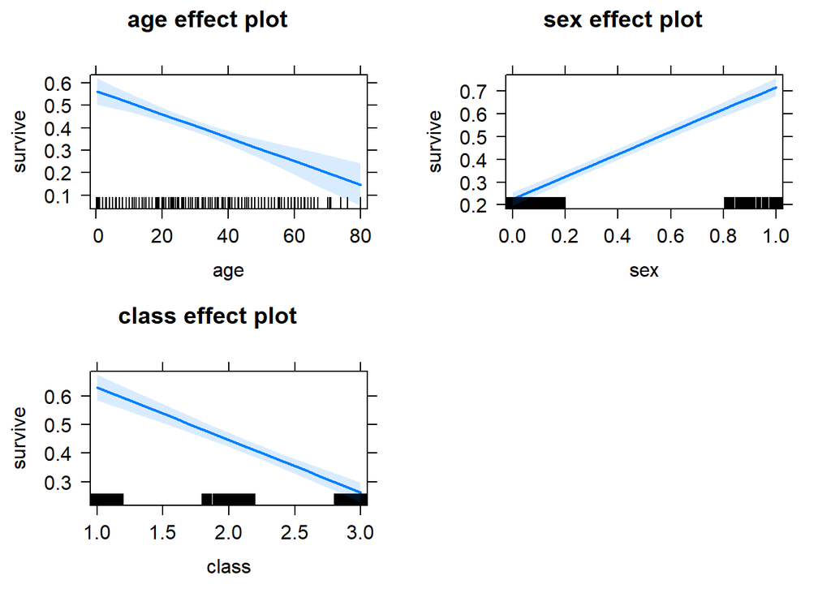

```r
plot(allEffects(best.model))
```

Figure 6. The effect of each predictor variable (age, sex, and class) on the probability of survival. Each predictor variable had the expected effect on the response variable. Younger individuals were more likely to survive. Females were more liekly to surive than males. People in a higher class (e.g. 1st class) were more likely to survive than those in a lower class.

## Question 9.

```r
library(car)
```

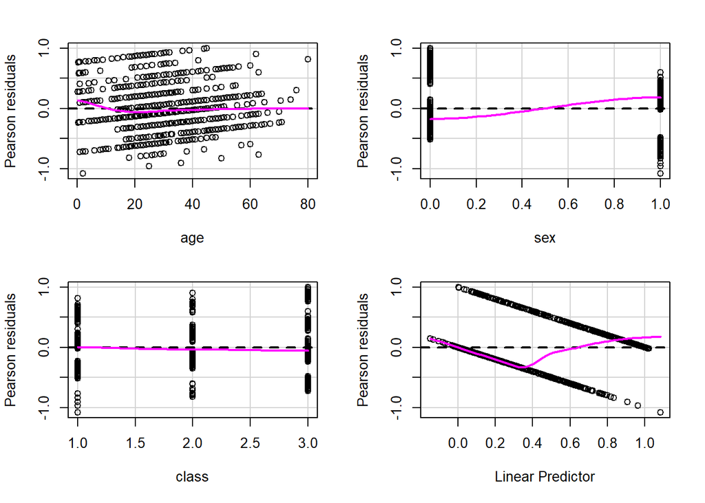

```
##       Test stat Pr(>|Test stat|)
## age      0.3609           0.5480
## sex      0.0000           1.0000
## class    0.1303           0.7181
```

```r
residualPlots(best.model)
```

Figure 7. Residuals vs fitted values for each predictor variable and full model. There are no trends in the residuals and fitted values for any variables which require attention

```r
outlierTest(best.model)
```

```
## No Studentized residuals with Bonferroni p < 0.05
## Largest |rstudent|:
##     rstudent unadjusted p-value Bonferroni p
## 25 -2.792323          0.0052331           NA
```

The Bonferroni p shows that there is not outliers.

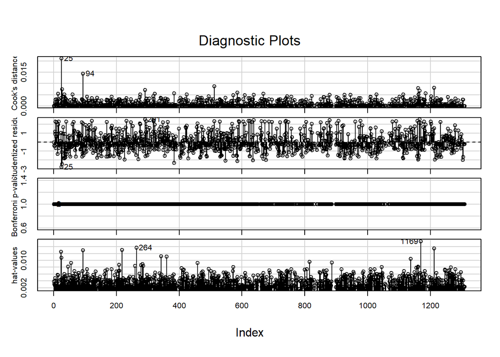

```r
influenceIndexPlot(best.model, id.n=3)
```

Figure 8. Influence of points expressed through Cook’s D, studentized residuals, Bonferroni p values, and hat values. Point 25 and 94 have a disproportionately high Cook’s D, but they are not high enough to require attention. No points have a disproportionate influence in the other measures.

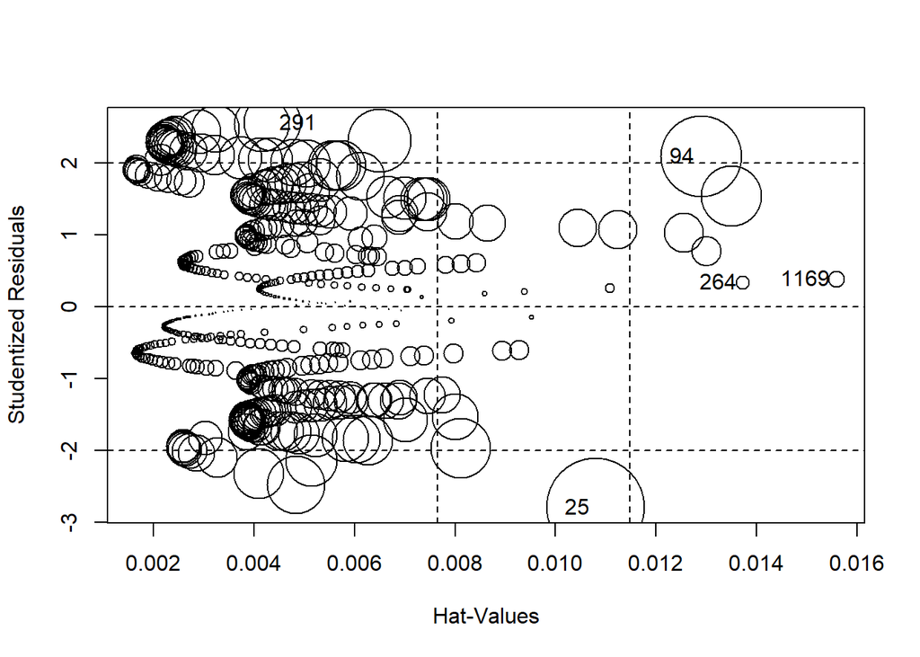

```
##         StudRes         Hat        CookD
## 25   -2.7923229 0.010799099 0.0211420873
## 94    2.0978766 0.012894099 0.0143255252
## 264   0.3369408 0.013729397 0.0003954327
## 291   2.5618051 0.004376314 0.0071734951
## 1169  0.3842430 0.015588639 0.0005849776
```

```r
influencePlot(best.model)
```

Point 25 and 94 have high hat-values and a relatively large Cook’s D. These data points were reviewed but they were not determined to be irregular or incorrect.

```r
vif(best.model)
```

```
##      age      sex    class
## 1.225582 1.040067 1.246724
```

Non of the VIFs are greater than 4 and do not require attention.

## Question 11

```r
library(caret)
ctrl <- trainControl(method = "repeatedcv", number = 10, savePredictions = TRUE)
survive.varsnona$survive=as.factor(survive.varsnona$survive)
train(survive~age+sex+class,data=survive.varsnona, method="glm", family=binomial(link='logit'),
                 trControl = ctrl, tuneLength = 5)
```

```
## Generalized Linear Model
##
## 1045 samples
##    3 predictor
##    2 classes: '0', '1'
##
## No pre-processing
## Resampling: Cross-Validated (10 fold, repeated 1 times)
## Summary of sample sizes: 941, 941, 940, 940, 940, 941, ...
## Resampling results:
##
##   Accuracy   Kappa
##   0.7818183  0.5440429
```

## Question 13

```r
predictions<-predict(best.model, newdata=survive.varsnona,type="response")
confusionMatrix(data=as.factor(as.numeric(predictions>0.5)),reference=survive.varsnona$survive)
```

```
## Confusion Matrix and Statistics
##
##           Reference
## Prediction   0   1
##          0 523 133
##          1  95 294
##
##                Accuracy : 0.7818
##                  95% CI : (0.7555, 0.8065)
##     No Information Rate : 0.5914
##     P-Value [Acc > NIR] : < 2e-16
##
##                   Kappa : 0.5423
##
##  Mcnemar's Test P-Value : 0.01427
##
##             Sensitivity : 0.8463
##             Specificity : 0.6885
##          Pos Pred Value : 0.7973
##          Neg Pred Value : 0.7558
##              Prevalence : 0.5914
##          Detection Rate : 0.5005
##    Detection Prevalence : 0.6278
##       Balanced Accuracy : 0.7674
##
##        'Positive' Class : 0
##
```

The confusion matrix was accurate 78.18% of the time.